# Trafonun Kalan Yıl Ömrünü Tahmin Etme

Mustafa Danabaşı

08.03.2025

# Giriş

Bu raporda, trafo ömrü tahminlerinin doğruluğunu değerlendirmek için yapılan analizleri yorumlayacağız.

# Kullanılan Kütüphaneler

1. readr: CSV dosyalarını okumak için
2. ggplot2: Grafik oluşturmak için
3. caret: Veri setini eğitim ve test olarak bölmek için
4. dplyr: Veri işleme işlemleri için
5. knitr: R Markdown veya HTML/PDF raporları oluşturmak için kullanılır.

# CSV dosyasından Veri Okuma

# Veri kümesi üzerinde keşifsel çalışmalar

## Eksik değer kontrolü

```
## [1] 0
```

## Veri temizleme

Verilerimiz içinde Omur_Tahmini_Yil değeri 0 dan küçük kayıtları temizliyoruz ve yeni bir değişkene atıyoruz.

```
## # A tibble: 250 × 4
##      Yas Nem_Orani Ariza_Gecmisi Omur_Tahmini_Yil
##    <dbl>     <dbl>         <dbl>            <dbl>
##  1    39      36.1            20                5
##  2    29      27.6            15               11
##  3    15      66.9             6               21
##  4    43      74.8            12                5
##  5     8      37.9            20               13
##  6    21      17.7             9               28
##  7    39      85.2             6                5
##  8    19      41.8            13               16
##  9    23      51.4             4               24
## 10    11      77.0             2               27
## # ℹ 240 more rows
```

## İlk 10 satırı gösterme

```
## # A tibble: 10 × 4
##      Yas Nem_Orani Ariza_Gecmisi Omur_Tahmini_Yil
##    <dbl>     <dbl>         <dbl>            <dbl>
##  1    39      36.1            20                5
##  2    29      27.6            15               11
##  3    15      66.9             6               21
##  4    43      74.8            12                5
##  5     8      37.9            20               13
##  6    21      17.7             9               28
##  7    39      85.2             6                5
##  8    19      41.8            13               16
##  9    23      51.4             4               24
## 10    11      77.0             2               27
```

## Veri seti hakkında bilgi

```
## spc_tbl_ [250 × 4] (S3: spec_tbl_df/tbl_df/tbl/data.frame)
##  $ Yas             : num [1:250] 39 29 15 43 8 21 39 19 23 11 ...
##  $ Nem_Orani       : num [1:250] 36.1 27.6 66.9 74.8 37.9 ...
##  $ Ariza_Gecmisi   : num [1:250] 20 15 6 12 20 9 6 13 4 2 ...
##  $ Omur_Tahmini_Yil: num [1:250] 5 11 21 5 13 28 5 16 24 27 ...
##  - attr(*, "spec")=
##   .. cols(
##   ..   Yas = col_double(),
##   ..   Nem_Orani = col_double(),
##   ..   Ariza_Gecmisi = col_double(),
##   ..   Omur_Tahmini_Yil = col_double()
##   .. )
##  - attr(*, "problems")=<externalptr>
```

## Satır ve sütun sayısı

```
## [1] 250   4
```

## Veri setini inceleyelim

```
## # A tibble: 6 × 4
##     Yas Nem_Orani Ariza_Gecmisi Omur_Tahmini_Yil
##   <dbl>     <dbl>         <dbl>            <dbl>
## 1    39      36.1            20                5
## 2    29      27.6            15               11
## 3    15      66.9             6               21
## 4    43      74.8            12                5
## 5     8      37.9            20               13
## 6    21      17.7             9               28
```

## Veri seti özet istatistikleri

```
##       Yas          Nem_Orani     Ariza_Gecmisi   Omur_Tahmini_Yil
##  Min.   : 1.00   Min.   :10.41   Min.   : 0.00   Min.   : 5.00
##  1st Qu.:12.00   1st Qu.:30.86   1st Qu.: 4.25   1st Qu.: 5.00
##  Median :25.00   Median :49.59   Median :10.00   Median :14.50
##  Mean   :24.89   Mean   :50.02   Mean   :10.05   Mean   :16.59
##  3rd Qu.:37.00   3rd Qu.:68.22   3rd Qu.:16.00   3rd Qu.:25.75
##  Max.   :50.00   Max.   :89.70   Max.   :20.00   Max.   :50.00
```

## Veri yapısını inceleme

```
## spc_tbl_ [250 × 4] (S3: spec_tbl_df/tbl_df/tbl/data.frame)
##  $ Yas             : num [1:250] 39 29 15 43 8 21 39 19 23 11 ...
##  $ Nem_Orani       : num [1:250] 36.1 27.6 66.9 74.8 37.9 ...
##  $ Ariza_Gecmisi   : num [1:250] 20 15 6 12 20 9 6 13 4 2 ...
##  $ Omur_Tahmini_Yil: num [1:250] 5 11 21 5 13 28 5 16 24 27 ...
##  - attr(*, "spec")=
##   .. cols(
##   ..   Yas = col_double(),
##   ..   Nem_Orani = col_double(),
##   ..   Ariza_Gecmisi = col_double(),
##   ..   Omur_Tahmini_Yil = col_double()
##   .. )
##  - attr(*, "problems")=<externalptr>
```

# Görselleştirme

## Trafonun yaşı ile tahmini ömrü arasındaki ilişkisi dağılım grafiği

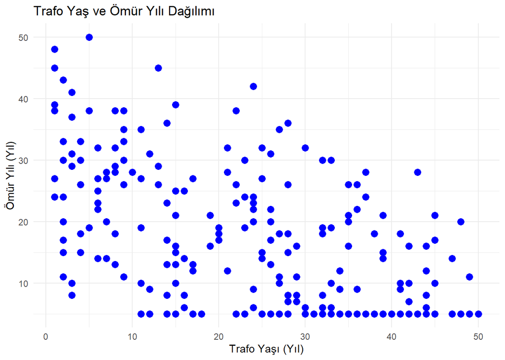

## Yaş ve ömür arasındaki değişimi çizgi grafiği

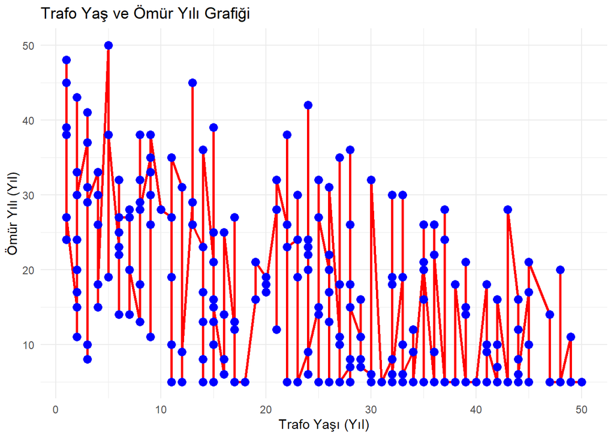

## Yaş ve ömür arasındaki ilişki

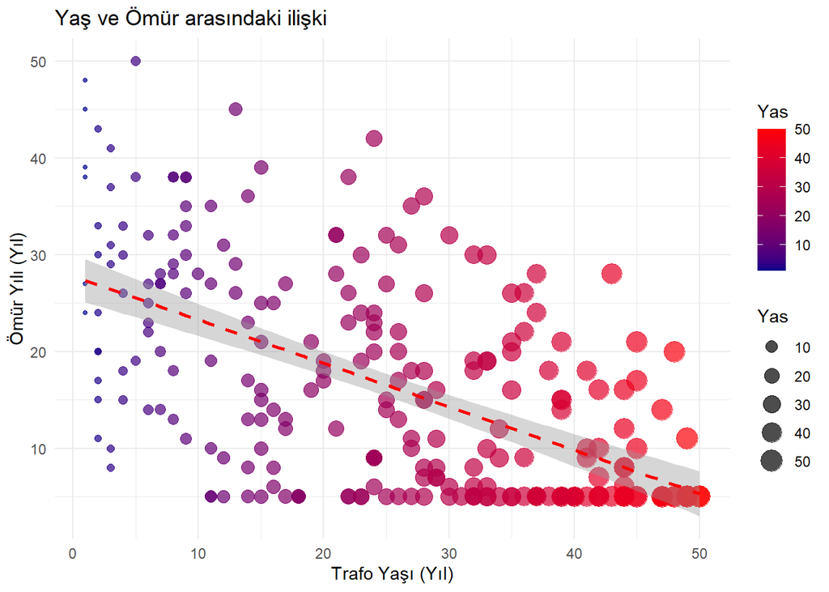

# Regresyon Analizi

Rastgelelik kontrolü. Eğer 1 yapılırsa devamlı aynı veri üzerinde test ve eğitim yapılacaktır.

%80 eğitim, %20 test veri seti olarak ayır. 250 adet verimiz vardı. 201 adetini eğitim 49 adetini test için ayırıyoruz.

## Eğitim ve test veri setlerini oluştur

```
##       Yas          Nem_Orani     Ariza_Gecmisi   Omur_Tahmini_Yil
##  Min.   : 1.00   Min.   :10.41   Min.   : 0.00   Min.   : 5.00
##  1st Qu.:11.00   1st Qu.:30.86   1st Qu.: 4.00   1st Qu.: 5.00
##  Median :24.00   Median :51.33   Median :10.00   Median :15.00
##  Mean   :24.44   Mean   :50.70   Mean   : 9.91   Mean   :16.74
##  3rd Qu.:36.00   3rd Qu.:69.53   3rd Qu.:15.00   3rd Qu.:26.00
##  Max.   :50.00   Max.   :89.56   Max.   :20.00   Max.   :50.00
```

```
##       Yas          Nem_Orani     Ariza_Gecmisi   Omur_Tahmini_Yil
##  Min.   : 1.00   Min.   :13.11   Min.   : 0.00   Min.   : 5.00
##  1st Qu.:15.00   1st Qu.:30.87   1st Qu.: 5.00   1st Qu.: 5.00
##  Median :32.00   Median :45.39   Median :11.00   Median :14.00
##  Mean   :26.73   Mean   :47.26   Mean   :10.63   Mean   :15.96
##  3rd Qu.:39.00   3rd Qu.:59.27   3rd Qu.:16.00   3rd Qu.:24.00
##  Max.   :50.00   Max.   :89.70   Max.   :20.00   Max.   :45.00
```

```
## [1] 201   4
```

```
## [1] 49  4
```

## Doğrusal regresyon modelini eğitim seti üzerinden oluşturulur

## Modelin özetini görüntüle

```
##
## Call:
## lm(formula = .outcome ~ ., data = dat)
##
## Residuals:
##    Min     1Q Median     3Q    Max
## -4.351 -2.723 -0.674  1.614 18.884
##
## Coefficients:
##               Estimate Std. Error t value Pr(>|t|)
## (Intercept)   50.88670    0.84891   59.94   <2e-16 ***
## Yas           -0.45978    0.01716  -26.80   <2e-16 ***
## Nem_Orani     -0.22757    0.01065  -21.37   <2e-16 ***
## Ariza_Gecmisi -1.14755    0.04023  -28.53   <2e-16 ***
## ---
## Signif. codes:  0 '***' 0.001 '**' 0.01 '*' 0.05 '.' 0.1 ' ' 1
##
## Residual standard error: 3.521 on 197 degrees of freedom
## Multiple R-squared:  0.9044, Adjusted R-squared:  0.9029
## F-statistic: 620.9 on 3 and 197 DF,  p-value: < 2.2e-16
```

```
##
## Call:
## lm(formula = .outcome ~ ., data = dat)
##
## Residuals:
##    Min     1Q Median     3Q    Max
## -4.351 -2.723 -0.674  1.614 18.884
##
## Coefficients:
##               Estimate Std. Error t value Pr(>|t|)
## (Intercept)   50.88670    0.84891   59.94   <2e-16 ***
## Yas           -0.45978    0.01716  -26.80   <2e-16 ***
## Nem_Orani     -0.22757    0.01065  -21.37   <2e-16 ***
## Ariza_Gecmisi -1.14755    0.04023  -28.53   <2e-16 ***
## ---
## Signif. codes:  0 '***' 0.001 '**' 0.01 '*' 0.05 '.' 0.1 ' ' 1
##
## Residual standard error: 3.521 on 197 degrees of freedom
## Multiple R-squared:  0.9044, Adjusted R-squared:  0.9029
## F-statistic: 620.9 on 3 and 197 DF,  p-value: < 2.2e-16
```

## Model ile test seti üzerinde tahmin yap

```
##          1          2          3          4          5          6          7
##  0.3324928 15.6349569  6.6720142 19.7756530  4.2957859 17.1884985  9.7951246
##          8          9         10         11         12         13         14
## 29.9534517 16.7788726  1.7094693 30.9154185 27.3085815 21.3620222  5.1160491
##         15         16         17         18         19         20         21
## 30.1214062  7.7518221 -1.4052947 23.6719764 12.8920815 16.1782628 40.0434765
##         22         23         24         25         26         27         28
## -1.1128216 29.8695998  8.0823852  3.1880790 -3.1299879 28.1402194 -1.0556986
##         29         30         31         32         33         34         35
## 20.8190274 26.8871495 29.2697636 35.1518424 20.0593208 18.5216582 10.9185612
##         36         37         38         39         40         41         42
## 11.5330425 23.6682976 35.3837937 18.6003506 11.6980624  1.5700624 25.6976873
##         43         44         45         46         47         48         49
## 17.1510795 12.3236265  2.3057625  5.0493298 10.1185478 10.0521919 19.4557692
```

## Gerçek değerler ve tahminleri karşılaştıran bir veri çerçevesi oluştur

```
##    Gercek     Tahmin
## 1       5  0.3324928
## 2      13 15.6349569
## 3       5  6.6720142
## 4      19 19.7756530
## 5       5  4.2957859
## 6      15 17.1884985
## 7       6  9.7951246
## 8      32 29.9534517
## 9      15 16.7788726
## 10      5  1.7094693
## 11     33 30.9154185
## 12     29 27.3085815
## 13     21 21.3620222
## 14      5  5.1160491
```

[output cut: 35 more lines]

## Mean Absolute Error (MAE) ve Root Mean Squared Error (RMSE) hesaplama

```
## Mean Absolute Error (MAE): 2.58669
```

```
## Root Mean Squared Error (RMSE): 3.126183
```

## Gerçek ve Tahmin Verilerinin Karşılaştırılmasının Görselleştirilmesi

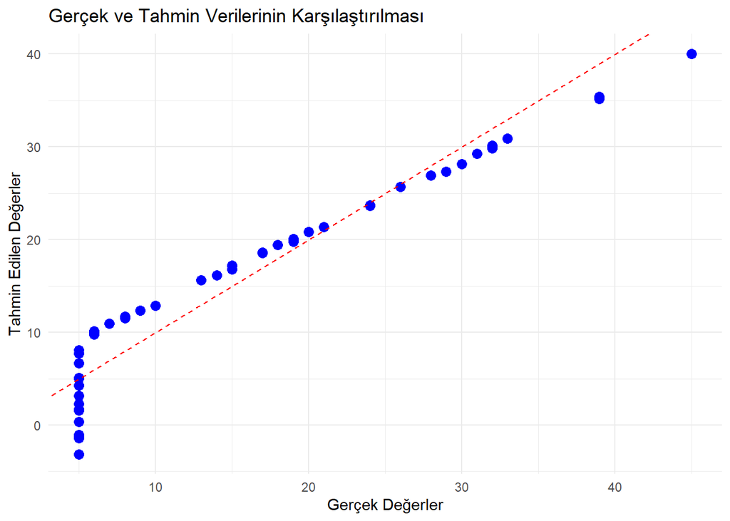

# Sonuçlar ve Yorumlar

Bu çalışmada elektrik dağıtım trafolarının ömrünü yıl bazında tahmin etmek için çalışmalar yapılmış ve bazı sonuçlara varılmıştır.

MAE = 2.59, yani modelin tahminleri ortalama 2.59 yıl sapma gösteriyor. RMSE = 3.13, yani modelde büyük hatalar varsa bunlar ortalama 3.13 yıl sapmaya neden oluyor. RMSE’nin MAE’den biraz büyük olması, modelde bazı büyük hatalar olduğunu gösteriyor ama aşırı büyük sapmalar olmadığını söyleyebiliriz.

Hataları düşürmek için daha fazla özellik ve veri ile tahmin yapılması daha iyi olacaktır.